# Examen 2 Herramientas de Ciencia de Datos I

Author

Andrey González Bastos C33329

Published

November 30, 2025

#Punto 1

Cargar la base de datos y librerías

```r
#Se cargan las librerías necesarias

library(readr)
library(readxl)
library(dplyr)
library(ggplot2)

#Se carga la base de datos corrigiendo las comas y eso de las columnas numéricas

moras <- read.csv(
  "C:/Users/XPC/Desktop/Examen2_CA0204/data/moras.txt",
  stringsAsFactors = FALSE,
  header = TRUE
)

#Limpieza de comas y demás de la columna salario para evitar errores de lectura

moras$SALARIO <- gsub('"', '', moras$SALARIO)
moras$SALARIO <- gsub("[^0-9,]", "", moras$SALARIO)
moras$SALARIO <- gsub(",", ".", moras$SALARIO)
moras$SALARIO <- as.numeric(moras$SALARIO)
```

#Punto 2

Resumen de los cinco números

```r
summary(moras$SALARIO)
```

```
    Min.  1st Qu.   Median     Mean  3rd Qu.     Max.     NA's
      10   297429   408495   657534   700000 16858742        3
```

```r
summary(moras$EDAD)
```

```
   Min. 1st Qu.  Median    Mean 3rd Qu.    Max.    NA's
  14.00   31.00   40.00   41.91   52.00   99.00       3
```

#Punto 3

```r
#Se crea una función para hacer ese cálculo más rápido para todas las entradas del vector

z.scores.funcion <- function(vector){
  media = mean(vector, na.rm = TRUE)
  sd = sd(vector, na.rm = TRUE)
  z.score = (vector -media)/sd
  return(z.score)

}

#Se le hacen las nuevas columnas al moras original
moras <- moras %>% mutate(
z.score.salario = z.scores.funcion(moras$SALARIO),
z.score.edad = z.scores.funcion(moras$EDAD)
)

#Se comprueba que todo salió bien con un head

moras %>% head(5)
```

|  | IDENTIFICACION | SEXO | SALARIO | TIPO_ASEGURAMIENTO | SECTOR | INDICADOR_ACTIVO | INDICADOR.EXTRANJERO | INDICADOR_MOROSO | EDAD | z.score.salario | z.score.edad |
| --- | --- | --- | --- | --- | --- | --- | --- | --- | --- | --- | --- |
| 1 | 1 | HOMBRE | NA | ASALARIADO | SECTOR PUBLICO | SI | NO | NO | 42 | NA | 0.006609817 |
| 2 | 2 | HOMBRE | 3315014.0 | PENSIONADOS EN SU PROPIO SISTEMA | SECTOR PUBLICO | SI | NO | NO | 77 | 3.2767840 | 2.476746369 |
| 3 | 3 | MUJER | 270486.0 | ASALARIADO | SECTOR PRIVADO | SI | NO | NO | 45 | -0.4772468 | 0.218335807 |
| 4 | 4 | MUJER | 544949.8 | ASALARIADO | SECTOR PRIVADO | SI | NO | NO | 49 | -0.1388214 | 0.500637127 |
| 5 | 5 | MUJER | 210000.0 | ASALARIADO | SECTOR PRIVADO | SI | NO | NO | 42 | -0.5518286 | 0.006609817 |

```r
#Se hace la función para verificar rangos de z.score según la instrucción del 1.96

clasificadora.de.atipicos <- function(vector){
  resultado = ifelse(abs(vector)>1.96, "Atípico", "Normal")
  return(resultado)
}

#Se actualiza el dataframe

moras <- moras %>% mutate(
rango.z.salario = clasificadora.de.atipicos(z.score.salario),
rango.z.edad = clasificadora.de.atipicos(z.score.edad)
)

#Se hace un head pequeño para comprobar que todo salió bien

moras %>% head(5)
```

|  | IDENTIFICACION | SEXO | SALARIO | TIPO_ASEGURAMIENTO | SECTOR | INDICADOR_ACTIVO | INDICADOR.EXTRANJERO | INDICADOR_MOROSO | EDAD | z.score.salario | z.score.edad | rango.z.salario | rango.z.edad |
| --- | --- | --- | --- | --- | --- | --- | --- | --- | --- | --- | --- | --- | --- |
| 1 | 1 | HOMBRE | NA | ASALARIADO | SECTOR PUBLICO | SI | NO | NO | 42 | NA | 0.006609817 | NA | Normal |
| 2 | 2 | HOMBRE | 3315014.0 | PENSIONADOS EN SU PROPIO SISTEMA | SECTOR PUBLICO | SI | NO | NO | 77 | 3.2767840 | 2.476746369 | Atípico | Atípico |
| 3 | 3 | MUJER | 270486.0 | ASALARIADO | SECTOR PRIVADO | SI | NO | NO | 45 | -0.4772468 | 0.218335807 | Normal | Normal |
| 4 | 4 | MUJER | 544949.8 | ASALARIADO | SECTOR PRIVADO | SI | NO | NO | 49 | -0.1388214 | 0.500637127 | Normal | Normal |
| 5 | 5 | MUJER | 210000.0 | ASALARIADO | SECTOR PRIVADO | SI | NO | NO | 42 | -0.5518286 | 0.006609817 | Normal | Normal |

#Punto 4

```r
#Para este punto también se opta por hacer una función

porcentaje.na <- function(vector) {
  total = length(vector)
  nas = sum(is.na(vector))
  return((nas / total) * 100)
}

#Con sapply recorremos todo sin usar for ni varas raras

sapply(moras, porcentaje.na)
```

```
      IDENTIFICACION                 SEXO              SALARIO
                0.00                 0.00                 0.06
  TIPO_ASEGURAMIENTO               SECTOR     INDICADOR_ACTIVO
                0.00                 0.00                 0.00
INDICADOR.EXTRANJERO     INDICADOR_MOROSO                 EDAD
                0.00                 0.00                 0.06
     z.score.salario         z.score.edad      rango.z.salario
                0.06                 0.06                 0.06
        rango.z.edad
                0.06
```

#Punto 5

```r
#Anteriormente se vio que solo los numéricos tienen valores faltantes, por lo que se aplica la siguiente función:

imputar.promedio <- function(x) {
  media <- mean(x, na.rm = TRUE)
  x[is.na(x)] <- media
  return(x)
}

#Se imputa el dataframe completo

moras<-moras %>% mutate(across(where(is.numeric), imputar.promedio))

#Se hace la verificación y ya todo quedó listo

colSums(is.na(moras))
```

```
      IDENTIFICACION                 SEXO              SALARIO
                   0                    0                    0
  TIPO_ASEGURAMIENTO               SECTOR     INDICADOR_ACTIVO
                   0                    0                    0
INDICADOR.EXTRANJERO     INDICADOR_MOROSO                 EDAD
                   0                    0                    0
     z.score.salario         z.score.edad      rango.z.salario
                   0                    0                    3
        rango.z.edad
                   3
```

#Punto 6

```
# A tibble: 2 × 2
  SEXO   cantidad
  <chr>     <int>
1 HOMBRE     3012
2 MUJER      1988
```

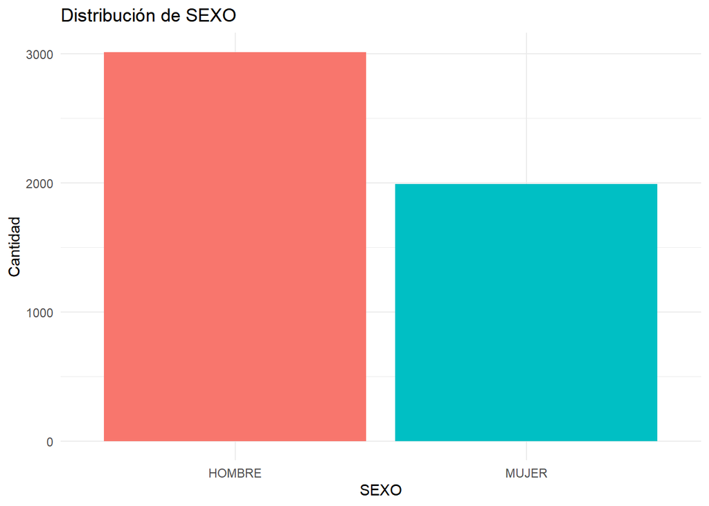

```
# A tibble: 7 × 2
  TIPO_ASEGURAMIENTO                                    cantidad
  <chr>                                                    <int>
1 ""                                                           2
2 "ASALARIADO"                                              3462
3 "ASEGURADO VOLUNTARIO"                                     436
4 "CONVENIOS ESPECIALES DE ASEGURADOS VOLUNTARIOS"            31
5 "CONVENIOS ESPECIALES DE TRABAJADORES INDEPENDIENTES"      157
6 "PENSIONADOS EN SU PROPIO SISTEMA"                         212
7 "TRABAJADOR INDEPENDIENTE"                                 700
```

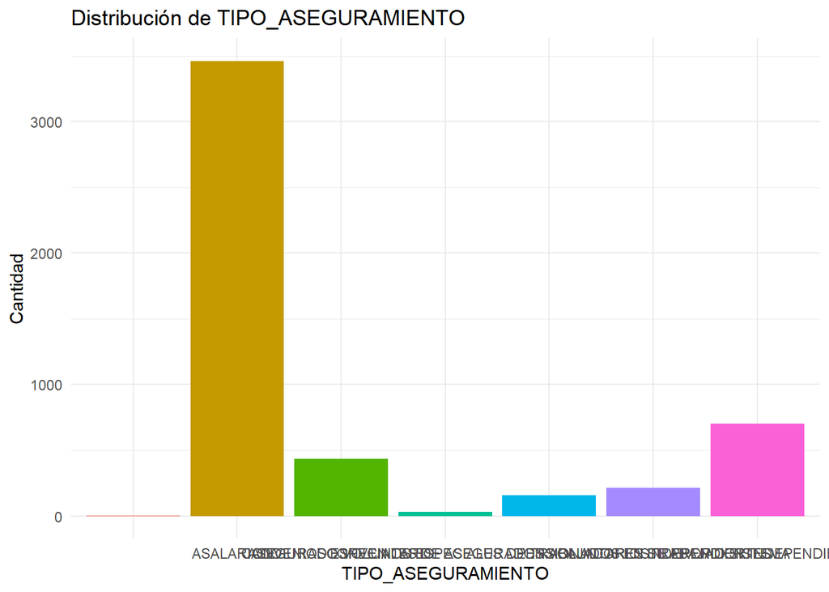

```
# A tibble: 2 × 2
  SECTOR         cantidad
  <chr>             <int>
1 SECTOR PRIVADO     3906
2 SECTOR PUBLICO     1094
```

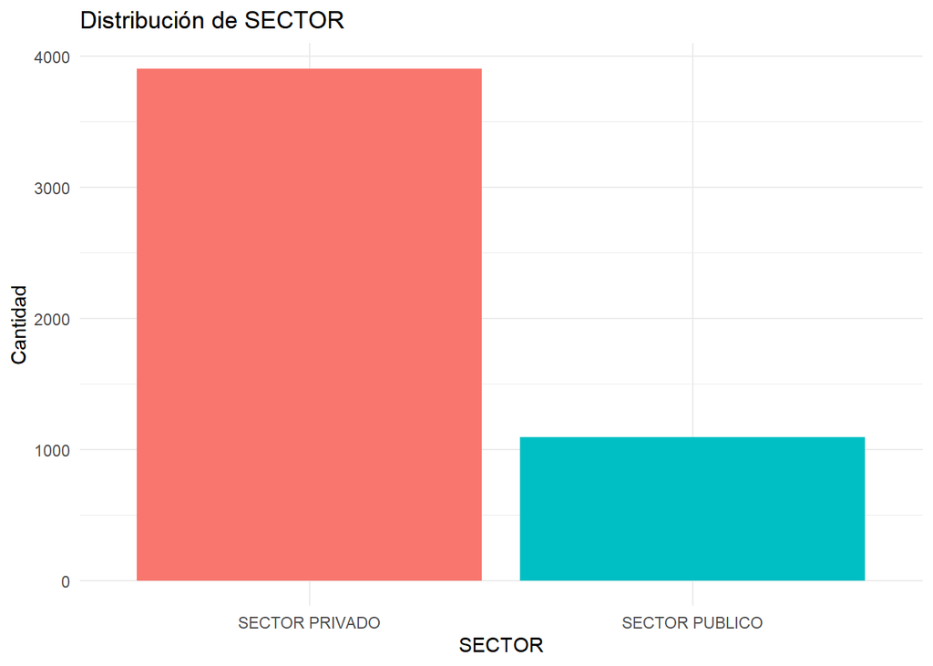

```
# A tibble: 2 × 2
  INDICADOR_ACTIVO cantidad
  <chr>               <int>
1 NO                     34
2 SI                   4966
```

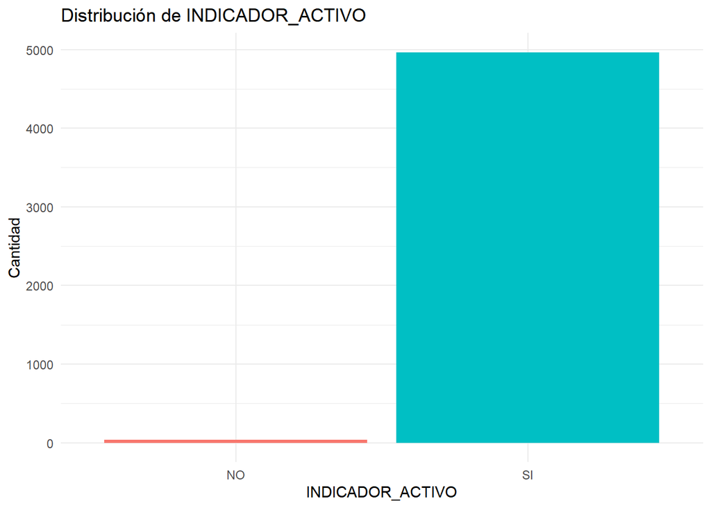

```
# A tibble: 2 × 2
  INDICADOR.EXTRANJERO cantidad
  <chr>                   <int>
1 NO                       4397
2 SI                        603
```

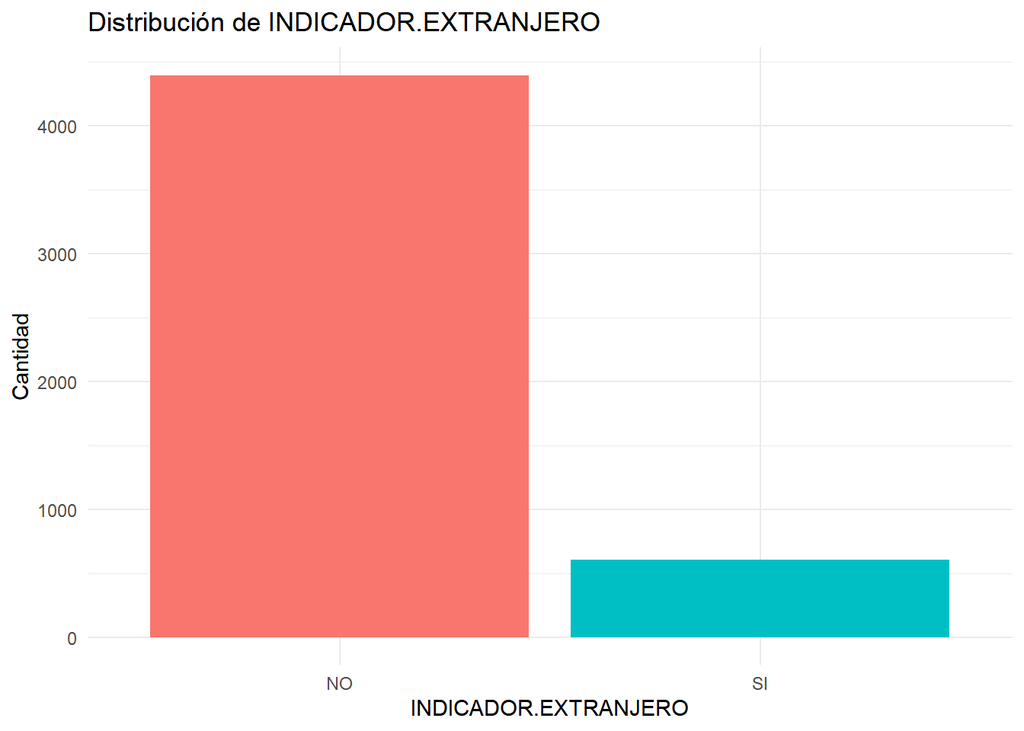

```
# A tibble: 2 × 2
  INDICADOR_MOROSO cantidad
  <chr>               <int>
1 NO                   4130
2 SI                    870
```

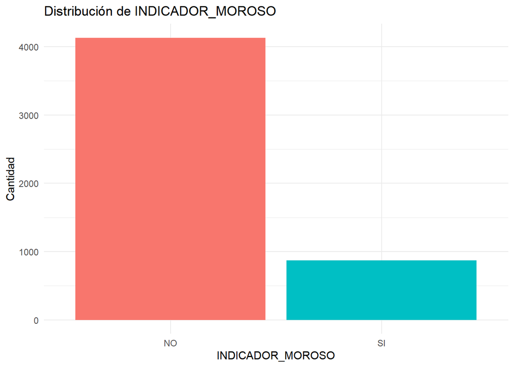

```
# A tibble: 3 × 2
  rango.z.salario cantidad
  <chr>              <int>
1 Atípico              162
2 Normal              4835
3 <NA>                   3
```

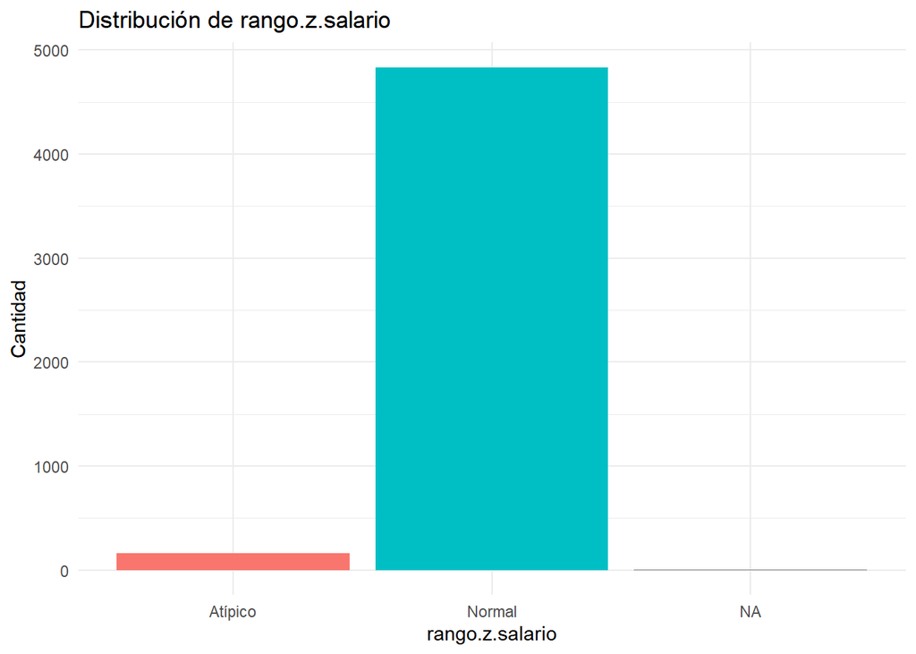

```
# A tibble: 3 × 2
  rango.z.edad cantidad
  <chr>           <int>
1 Atípico           182
2 Normal           4815
3 <NA>                3
```

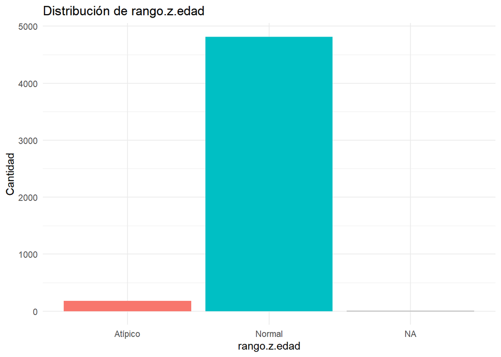

```r
#Para esto, será necesario hacer una función para graficar con for como en el examen pasado porque si no da navidad, entonces:


graficar.categoricas <- function(df) {

  categoricas <- names(df)[sapply(df, function(x)
    is.character(x) || is.factor(x))]

  for (var in categoricas) {
    resumen <- df %>%
      group_by(.data[[var]]) %>%
      summarise(cantidad = n(), .groups = "drop")
      print(resumen)

      p <- ggplot(resumen, aes(x = .data[[var]], y = cantidad, fill = .data[[var]])) +
        geom_bar(stat = "identity") +
        labs(title = paste("Distribución de", var),
             x = var,
             y = "Cantidad") +
        theme_minimal() +
        theme(legend.position = "none")

      print(p)
  }
}

graficar.categoricas(moras)
```

Este punto ayuda a ver como se distribuyen los datos de la columnas por las diferentes categorías que tienen,esto ayuda a hacerse una idea de donde se está trabajando y a cuales variables les debemos poner más atención en posteriores análisis. Por ejemplo hay mucho más sector privado, casi toda la data está activa, hay minoría de morosos, minoría de extranjeros y los tipos de aseguramiento están más repartidos.

#Punto 7

```
# A tibble: 2 × 4
  SEXO   total morosos porcentaje.morosos
  <chr>  <int>   <int>              <dbl>
1 HOMBRE  3012     534               17.7
2 MUJER   1988     336               16.9
```

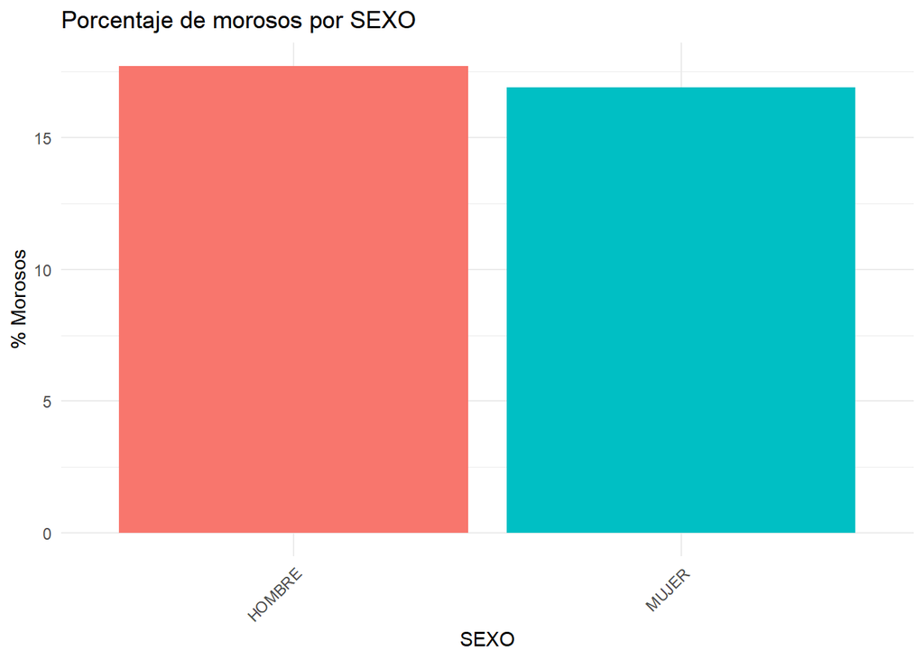

```
# A tibble: 7 × 4
  TIPO_ASEGURAMIENTO                            total morosos porcentaje.morosos
  <chr>                                         <int>   <int>              <dbl>
1 "TRABAJADOR INDEPENDIENTE"                      700     393              56.1
2 ""                                                2       1              50
3 "ASEGURADO VOLUNTARIO"                          436      58              13.3
4 "ASALARIADO"                                   3462     414              12.0
5 "CONVENIOS ESPECIALES DE TRABAJADORES INDEPE…   157       4               2.55
6 "CONVENIOS ESPECIALES DE ASEGURADOS VOLUNTAR…    31       0               0
7 "PENSIONADOS EN SU PROPIO SISTEMA"              212       0               0
```

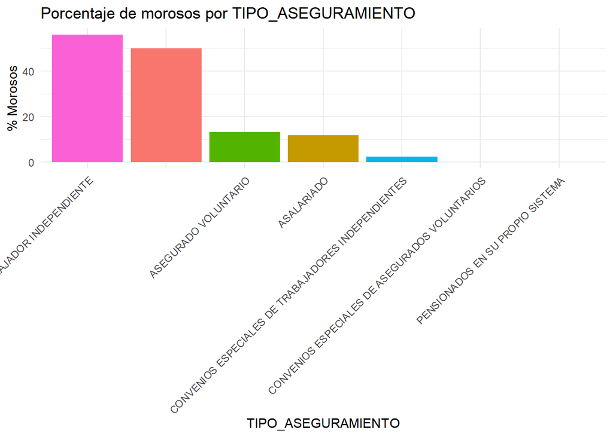

```
# A tibble: 2 × 4
  SECTOR         total morosos porcentaje.morosos
  <chr>          <int>   <int>              <dbl>
1 SECTOR PRIVADO  3906     704               18.0
2 SECTOR PUBLICO  1094     166               15.2
```

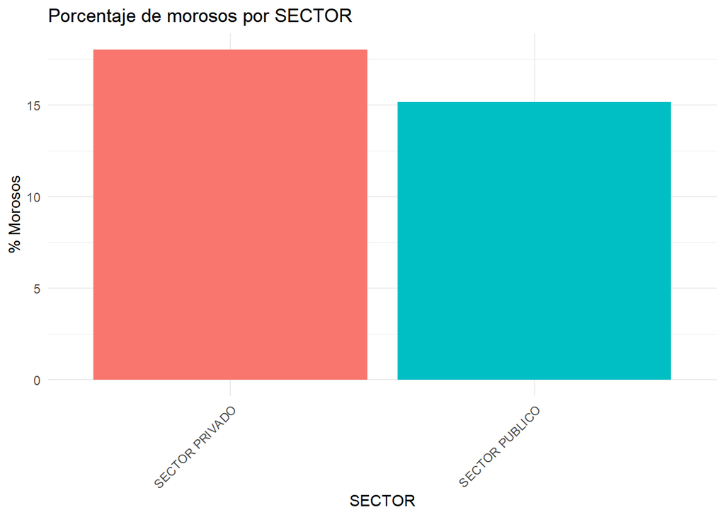

```
# A tibble: 2 × 4
  INDICADOR_ACTIVO total morosos porcentaje.morosos
  <chr>            <int>   <int>              <dbl>
1 NO                  34      18               52.9
2 SI                4966     852               17.2
```

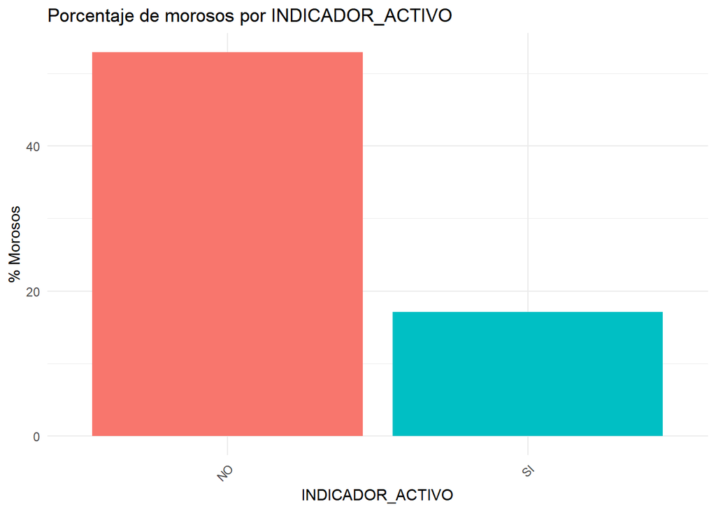

```
# A tibble: 2 × 4
  INDICADOR.EXTRANJERO total morosos porcentaje.morosos
  <chr>                <int>   <int>              <dbl>
1 SI                     603     145               24.0
2 NO                    4397     725               16.5
```

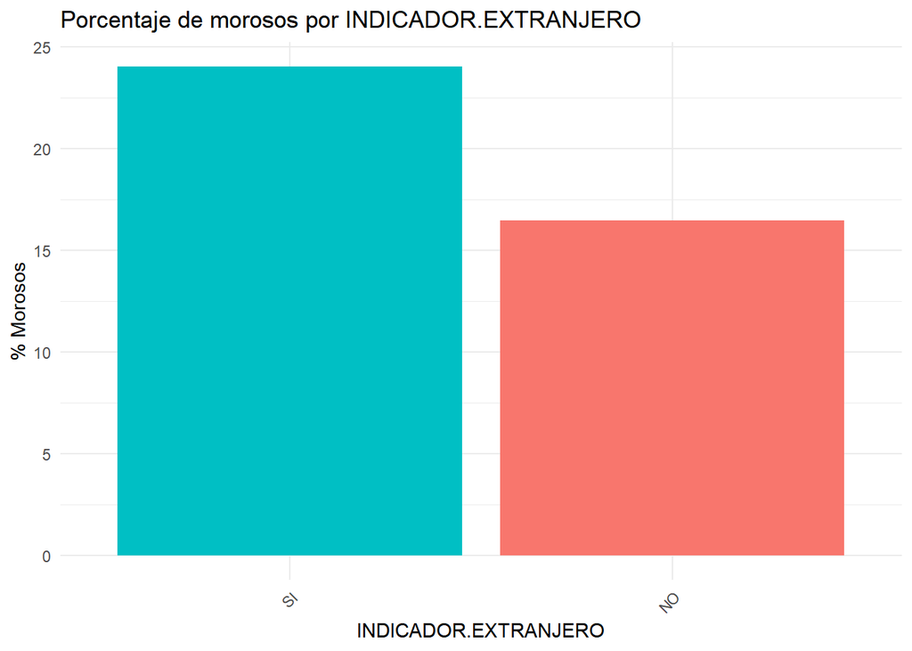

```
# A tibble: 2 × 4
  INDICADOR_MOROSO total morosos porcentaje.morosos
  <chr>            <int>   <int>              <dbl>
1 SI                 870     870                100
2 NO                4130       0                  0
```

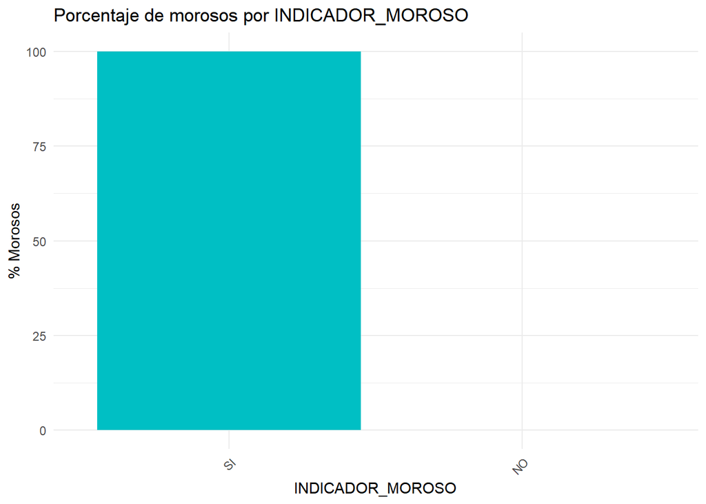

```
# A tibble: 3 × 4
  rango.z.salario total morosos porcentaje.morosos
  <chr>           <int>   <int>              <dbl>
1 Normal           4835     868              18.0
2 Atípico           162       2               1.23
3 <NA>                3       0               0
```

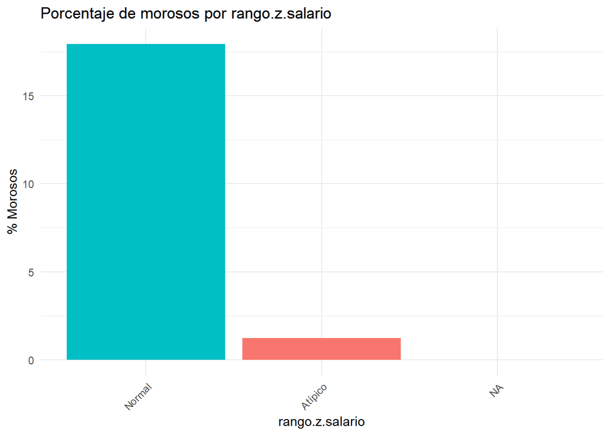

```
# A tibble: 3 × 4
  rango.z.edad total morosos porcentaje.morosos
  <chr>        <int>   <int>              <dbl>
1 Normal        4815     849               17.6
2 Atípico        182      21               11.5
3 <NA>             3       0                0
```

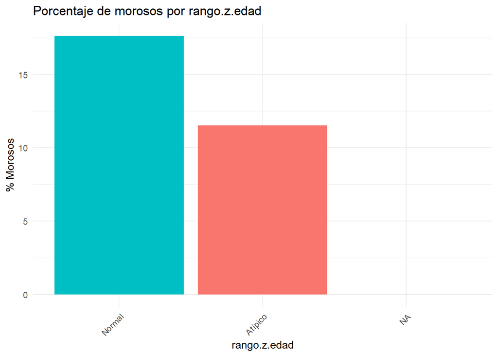

```r
#Para esto igual hay que recurrir a un for

graficar.morosos <- function(df, indicador = "INDICADOR_MOROSO") {

  categoricas <- names(df)[sapply(df, function(x) is.character(x) || is.factor(x))]

  for (var in categoricas) {
    resumen <- df %>%
      group_by(.data[[var]]) %>%
      summarise(
        total = n(),
        morosos = sum(.data[[indicador]] %in% c("SI"), na.rm = TRUE),
        porcentaje.morosos = (morosos / total) * 100,
        .groups = "drop"
      ) %>%
      arrange(desc(porcentaje.morosos))
      print(resumen)

      p <- ggplot(resumen, aes(
        x = reorder(.data[[var]], -porcentaje.morosos),
        y = porcentaje.morosos,
        fill = .data[[var]]
      )) +
        geom_bar(stat = "identity") +
        labs(
          title = paste("Porcentaje de morosos por", var),
          x = var,
          y = "% Morosos"
        ) +
        theme_minimal() +
        theme(axis.text.x = element_text(angle = 45, hjust = 1),
              legend.position = "none")

      print(p)
  }
}

graficar.morosos(moras)
```